# School belonging data analysis, logistic model

Author

Michael Kammer

Published

2025-06-30

# 1 Background

This frequentist analysis for the school belonging analysis task follows the statistical analysis plan by Michael Kammer dated 20.5.2025 (and referring to the task description for the simplified school belonging task with the same date that addresses a binary outcome variable). For a very brief initial data analysis we refer to `analysis_school-logistic-ida`.

# 2 Setup and data

Data were provided by Mariana Nold by mail on 3.1.2025 (`pisa2018.RData`). This dataset is already pre-processed with one small exception.

- ATT4 is computed by the `ggplot2::cut_number()` function, as outlined by Mariana in her SAP.
- bel01 is computed as the lowest 25% of students in terms of sense of belonging in `belong`.

```r
T_START = Sys.time()
SUFFIX = ""

# data handling and printing
library(tidyverse)
library(glue)
library(magrittr)
library(patchwork)
library(gtsummary)
library(gt)

# modelling
library(lme4)
library(MuMIn)
library(DHARMa)

# plotting
library(GGally)

# parallel
library(doFuture)

rm(list = c("pisa2018"))
load("Data/Raw/pisa2018.Rdata")

pisa2018 %<>% mutate(
        ATT4 = cut_number(ATT01, 4),
        bel01 = belong <= quantile(belong, probs = 0.25, na.rm = TRUE)
    )
levels(pisa2018$ATT4) = 1:4
```

## 2.1 Helper functions

Code for helper functions.

```r
logit = binomial()$linkfun
expit = binomial()$linkinv

plot_residuals_violin <- function(s, predictor, name = "Predictor") {
    res_data = data.frame(
        Residuals = residuals(s),
        Predictor = factor(predictor)
    )

    ggplot(res_data, aes(x = Predictor, y = Residuals)) +
        geom_violin(fill = "lightgrey", alpha = 0.6) +
        geom_jitter(width = 0.2, alpha = 0.5) +
        theme_minimal() +
        labs(title = paste("Predictor vs Residuals"), x = name, y = "Residuals")
}
```

# 3 Variables

As outlined in Table 1 in the task description.

```r
VARIABLES = list(
    outcome = "bel01",
    focal = c("bull", "ATT4"),
    nonfocal = c("female", "nld", "aca", "val", "nfof", "native", "joyread",
                 "goal", "mot", "res", "ndis_clim", "GYM", "UNI", "NDISH", "N_SC")
)

glue("{length(VARIABLES$nonfocal)} non-focal variables used for modeling according to SAP:
     {VARIABLES$nonfocal |> paste0(collapse = ', ')}")
```

```
15 non-focal variables used for modeling according to SAP:
female, nld, aca, val, nfof, native, joyread, goal, mot, res, ndis_clim, GYM, UNI, NDISH, N_SC
```

# 4 Analysis

## 4.1 Primary model

```r
f_m = sprintf("bel01 ~ bull * ATT4 + %s + (1 | school.id)",
              paste0(VARIABLES$nonfocal, collapse = " + ")) %>%
    as.formula()

m = glmer(f_m, data = pisa2018, family = binomial)
summary(m)
```

```
Generalized linear mixed model fit by maximum likelihood (Laplace
  Approximation) [glmerMod]
 Family: binomial  ( logit )
Formula: bel01 ~ bull * ATT4 + female + nld + aca + val + nfof + native +
    joyread + goal + mot + res + ndis_clim + GYM + UNI + NDISH +
    N_SC + (1 | school.id)
   Data: pisa2018

     AIC      BIC   logLik deviance df.resid
  6679.8   6842.5  -3315.9   6631.8     6465

Scaled residuals:
    Min      1Q  Median      3Q     Max
-4.3189 -0.5725 -0.4120  0.6129  4.8434

Random effects:
 Groups    Name        Variance Std.Dev.
 school.id (Intercept) 0.009786 0.09893
Number of obs: 6489, groups:  school.id, 221

Fixed effects:
            Estimate Std. Error z value Pr(>|z|)
(Intercept) -0.77754    0.17663  -4.402 1.07e-05 ***
bull         1.56754    0.20190   7.764 8.23e-15 ***
ATT42        0.05516    0.09788   0.564 0.573071
ATT43        0.30562    0.09736   3.139 0.001695 **
ATT44        0.34169    0.10110   3.380 0.000726 ***
female      -0.18707    0.06609  -2.830 0.004650 **
nld         -0.40875    0.08416  -4.857 1.19e-06 ***
aca          0.09258    0.06946   1.333 0.182584
val         -0.15853    0.03195  -4.962 6.99e-07 ***
nfof        -0.29604    0.03176  -9.320  < 2e-16 ***
native      -0.01788    0.08330  -0.215 0.830067
joyread      0.20206    0.03373   5.991 2.09e-09 ***
goal        -0.04179    0.03533  -1.183 0.236855
mot         -0.12944    0.03412  -3.794 0.000148 ***
res         -0.39537    0.03435 -11.509  < 2e-16 ***
ndis_clim    0.10698    0.03094   3.458 0.000545 ***
GYM         -0.25332    0.10087  -2.511 0.012026 *
UNI         -0.07970    0.20605  -0.387 0.698907
NDISH        0.08057    0.19825   0.406 0.684430
N_SC        -0.13707    0.20314  -0.675 0.499827
bull:ATT42  -0.33932    0.27628  -1.228 0.219383
bull:ATT43  -0.38631    0.26466  -1.460 0.144378
bull:ATT44  -0.44024    0.25952  -1.696 0.089822 .
---
Signif. codes:  0 '***' 0.001 '**' 0.01 '*' 0.05 '.' 0.1 ' ' 1
```

```
Correlation matrix not shown by default, as p = 23 > 12.
Use print(x, correlation=TRUE)  or
    vcov(x)        if you need it
```

### 4.1.1 Diagnostics

Calibration excluding and including random effects, respectively.

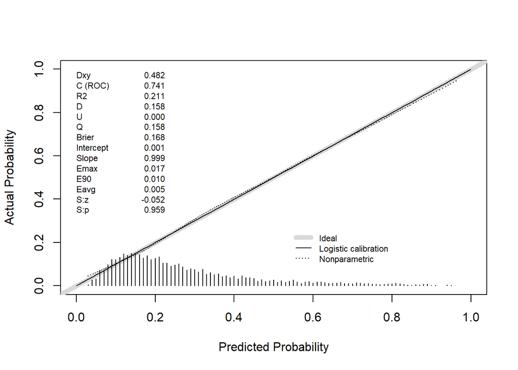

```
          Dxy       C (ROC)            R2             D      D:Chi-sq
 4.817855e-01  7.408927e-01  2.113194e-01  1.581486e-01  1.027226e+03
          D:p             U      U:Chi-sq           U:p             Q
           NA -3.074515e-04  4.947402e-03  9.975294e-01  1.584560e-01
        Brier     Intercept         Slope          Emax           E90
 1.675591e-01  7.575743e-04  9.987573e-01  1.700468e-02  9.941553e-03
         Eavg           S:z           S:p
 5.432070e-03 -5.175647e-02  9.587227e-01
```

```r
rms::val.prob(logit = predict(m, re.form = NA), y = pisa2018$bel01)
```

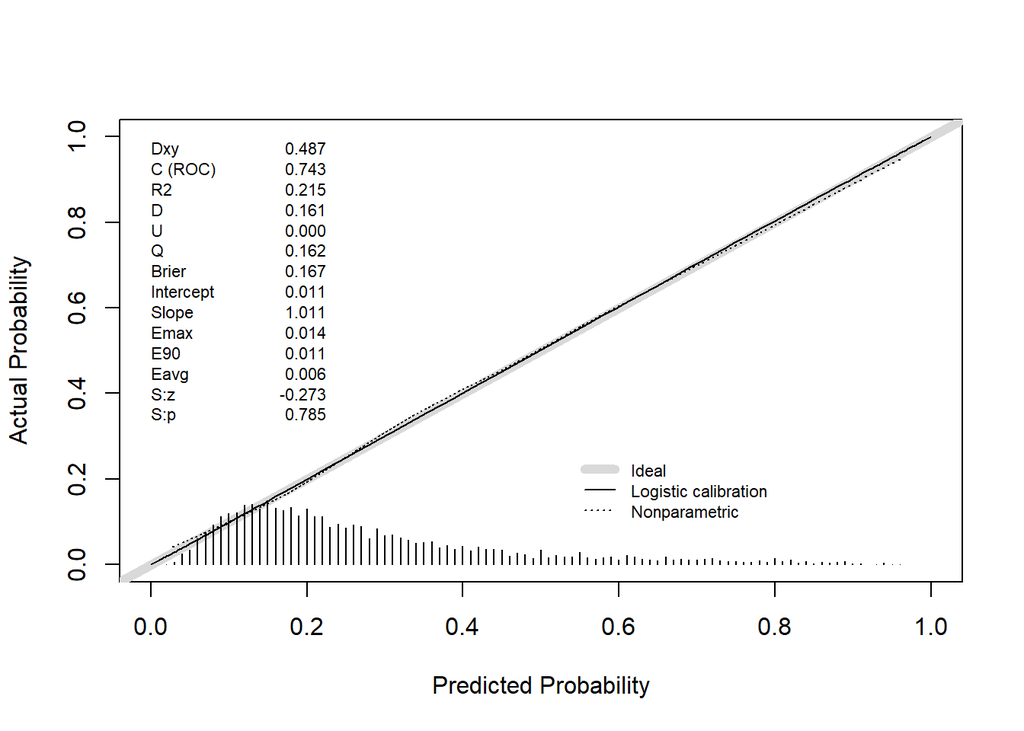

```
          Dxy       C (ROC)            R2             D      D:Chi-sq
 4.866069e-01  7.433035e-01  2.152595e-01  1.613517e-01  1.048011e+03
          D:p             U      U:Chi-sq           U:p             Q
           NA -2.937466e-04  9.387864e-02  9.541453e-01  1.616455e-01
        Brier     Intercept         Slope          Emax           E90
 1.669609e-01  1.079374e-02  1.010557e+00  1.411875e-02  1.080061e-02
         Eavg           S:z           S:p
 5.881688e-03 -2.731992e-01  7.847001e-01
```

```r
rms::val.prob(logit = predict(m, re.form = NULL), y = pisa2018$bel01)
```

Randomized quantile residuals. Note that outlier tests may have inflated error rates and are likely not relevant here.

```
DHARMa:testOutliers with type = binomial may have inflated Type I error rates for integer-valued distributions. To get a more exact result, it is recommended to re-run testOutliers with type = 'bootstrap'. See ?testOutliers for details
```

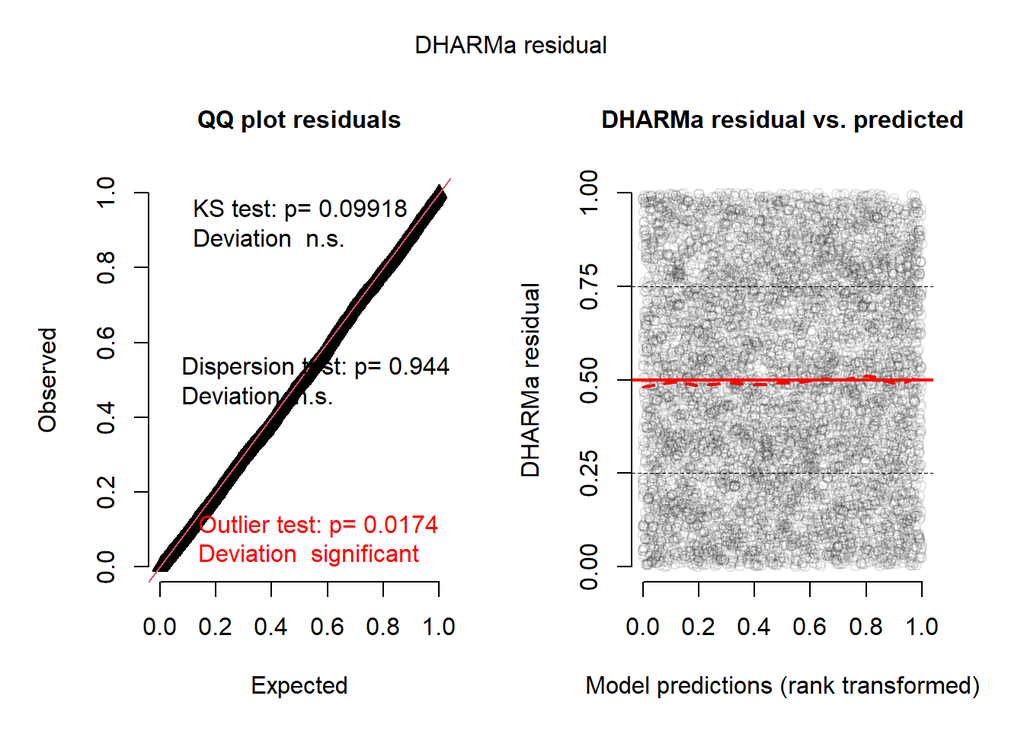

```r
s = simulateResiduals(m, seed = 26, plot = TRUE)
```

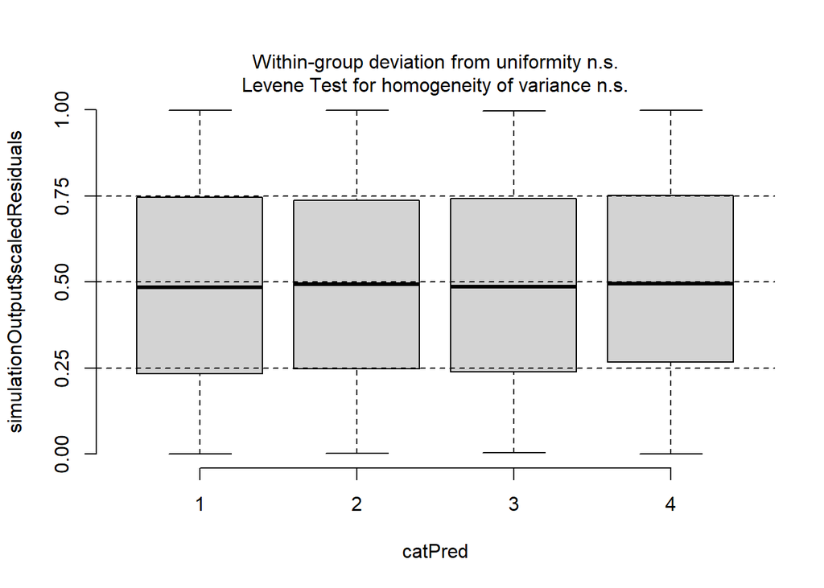

```r
plotResiduals(s, pisa2018$ATT4)
```

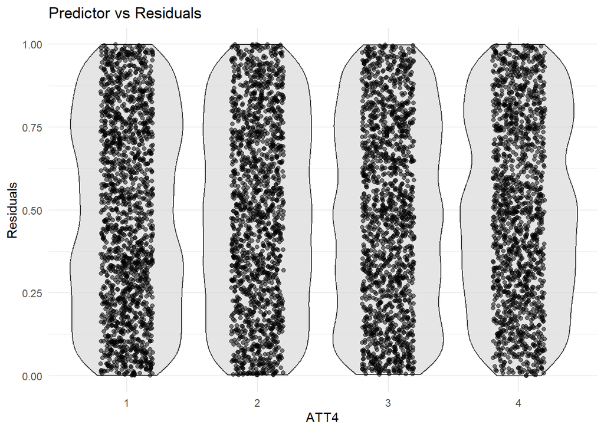

```r
plot_residuals_violin(s, pisa2018$ATT4, "ATT4")
```

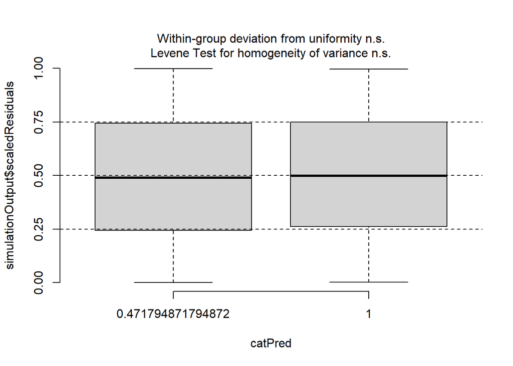

```r
plotResiduals(s, pisa2018$bull)
```

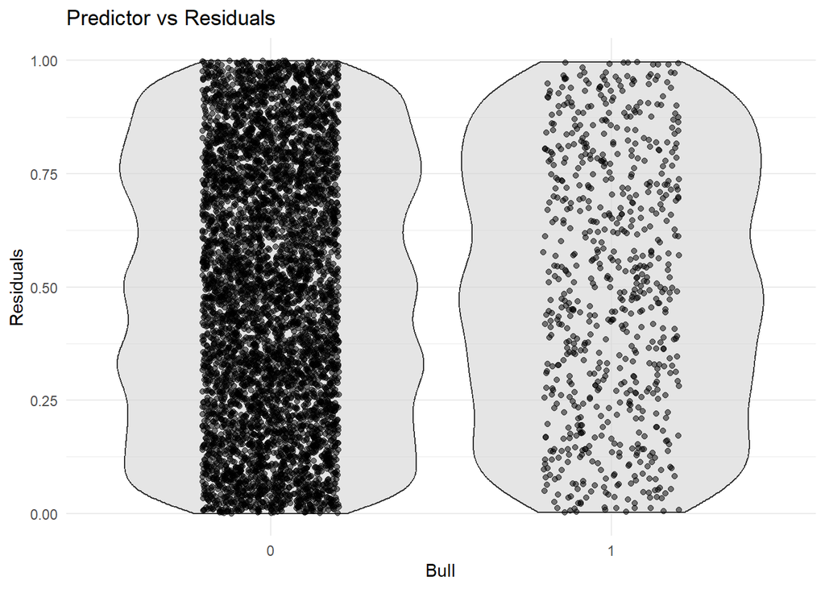

```r
plot_residuals_violin(s, pisa2018$bull, "Bull")
```

Random effect distribution (qq-plot for normality).

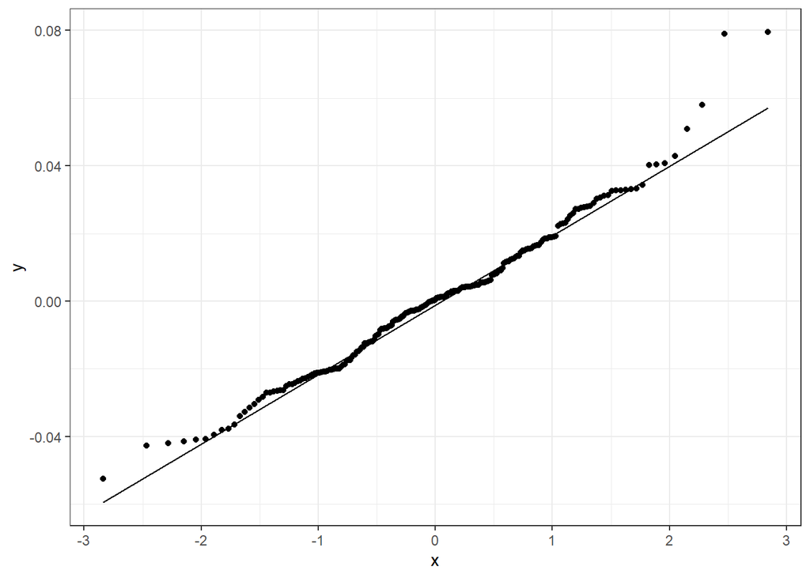

```r
ggplot(ranef(m)$school.id, aes(sample = `(Intercept)`)) +
        stat_qq() +
        stat_qq_line() +
        theme_bw()
```

### 4.1.2 Target estimands

Follow SAP to create representative students. We compute this for the full model only.

```r
preddf = pisa2018 %>%
    select(bull, ATT4, one_of(VARIABLES$nonfocal)) %>%
    # 1) create subsets of data by focal predictors
    group_by(bull, ATT4) %>%
    # 2) compute 1st, 2nd, 3rd quartiles in subsets
    reframe(
        across(everything(), ~ quantile(.x, probs = c(0.25, 0.5, 0.75))),
        quantile = 1:3
    )

# 3) apply models
preddf$pred_m = predict(m, newdata = preddf, re.form = NA)
preddf$pred_m_prob = expit(preddf$pred_m)

# 4) marginalize over random effect distribution
rf = ranef(m)$school.id[, 1]
preddf %<>%
    rowwise() %>%
    mutate(
        pred_m_marg = mean(pred_m + rf),
        pred_m_marg_prob = mean(expit(pred_m + rf))
    ) %>%
    ungroup()
```

Example: estimated probability and whole distribution due to random effect variation for a single representative student. All the estimated distributions have a common shape around their point estimate.

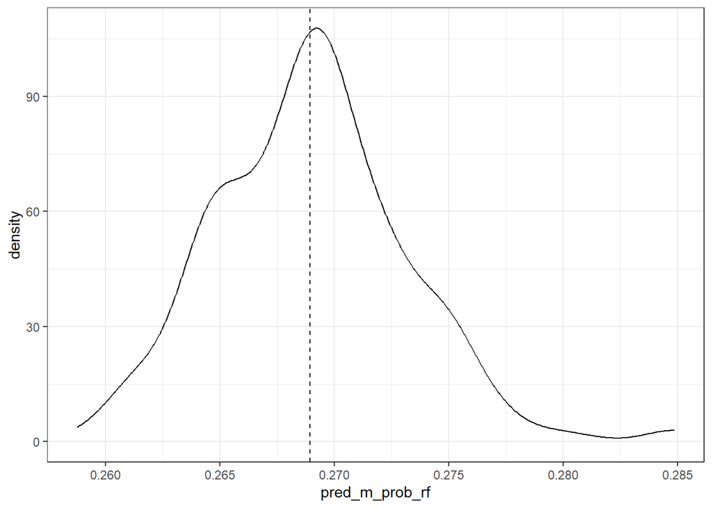

```r
i = 1
preddf_1 = data.frame(
    id = 1, pred_m = preddf$pred_m[i],
    pred_m_rf = preddf$pred_m[i] + rf,
    pred_m_prob_rf = expit(preddf$pred_m[i] + rf)
)

ggplot(preddf_1, aes(x = pred_m_prob_rf)) +
    geom_vline(xintercept = expit(preddf_1$pred_m[1]), linetype = "dashed") +
    geom_density() +
    theme_bw()
```

## 4.2 Secondary model

Note that the warning on model convergence from lme4 may often be regarded as false positive. The optimizer itself must report convergence.

```r
f_m2 = sprintf("bel01 ~ %s + (1 | school.id)",
              paste0(VARIABLES$nonfocal, collapse = " + ")) %>%
    as.formula()

m2 = glmer(f_m2, data = pisa2018, family = binomial)
```

```
Warning in checkConv(attr(opt, "derivs"), opt$par, ctrl = control$checkConv, :
Model failed to converge with max|grad| = 0.00898212 (tol = 0.002, component 1)
```

```r
summary(m2)
```

```
Generalized linear mixed model fit by maximum likelihood (Laplace
  Approximation) [glmerMod]
 Family: binomial  ( logit )
Formula: bel01 ~ female + nld + aca + val + nfof + native + joyread +
    goal + mot + res + ndis_clim + GYM + UNI + NDISH + N_SC +
    (1 | school.id)
   Data: pisa2018

     AIC      BIC   logLik deviance df.resid
  6878.3   6993.5  -3422.2   6844.3     6472

Scaled residuals:
    Min      1Q  Median      3Q     Max
-3.1937 -0.5969 -0.4316  0.7505  4.5175

Random effects:
 Groups    Name        Variance Std.Dev.
 school.id (Intercept) 0.03151  0.1775
Number of obs: 6489, groups:  school.id, 221

Fixed effects:
            Estimate Std. Error z value Pr(>|z|)
(Intercept) -0.14762    0.14715  -1.003 0.315744
female      -0.26903    0.06546  -4.110 3.96e-05 ***
nld         -0.49466    0.08220  -6.018 1.77e-09 ***
aca          0.08907    0.06856   1.299 0.193895
val         -0.18953    0.03131  -6.052 1.43e-09 ***
nfof        -0.31436    0.03123 -10.066  < 2e-16 ***
native      -0.01895    0.08223  -0.230 0.817777
joyread      0.22071    0.03329   6.629 3.38e-11 ***
goal        -0.04208    0.03476  -1.211 0.226075
mot         -0.12646    0.03360  -3.764 0.000167 ***
res         -0.41218    0.03382 -12.186  < 2e-16 ***
ndis_clim    0.15502    0.03015   5.142 2.72e-07 ***
GYM         -0.30829    0.10184  -3.027 0.002468 **
UNI         -0.13851    0.20901  -0.663 0.507537
NDISH        0.04521    0.20342   0.222 0.824132
N_SC        -0.28293    0.20256  -1.397 0.162481
---
Signif. codes:  0 '***' 0.001 '**' 0.01 '*' 0.05 '.' 0.1 ' ' 1
```

```
Correlation matrix not shown by default, as p = 16 > 12.
Use print(x, correlation=TRUE)  or
    vcov(x)        if you need it
```

```
optimizer (Nelder_Mead) convergence code: 0 (OK)
Model failed to converge with max|grad| = 0.00898212 (tol = 0.002, component 1)
```

### 4.2.1 Diagnostics

Calibration excluding and including random effects, respectively.

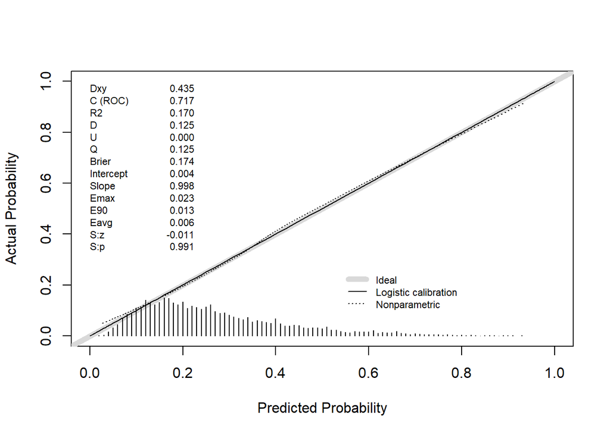

```
          Dxy       C (ROC)            R2             D      D:Chi-sq
 4.348062e-01  7.174031e-01  1.698118e-01  1.250133e-01  8.122116e+02
          D:p             U      U:Chi-sq           U:p             Q
           NA -3.018783e-04  4.111153e-02  9.796541e-01  1.253152e-01
        Brier     Intercept         Slope          Emax           E90
 1.744498e-01  4.127678e-03  9.980430e-01  2.323251e-02  1.318600e-02
         Eavg           S:z           S:p
 6.435272e-03 -1.132975e-02  9.909604e-01
```

```r
rms::val.prob(logit = predict(m2, re.form = NA), y = pisa2018$bel01)
```

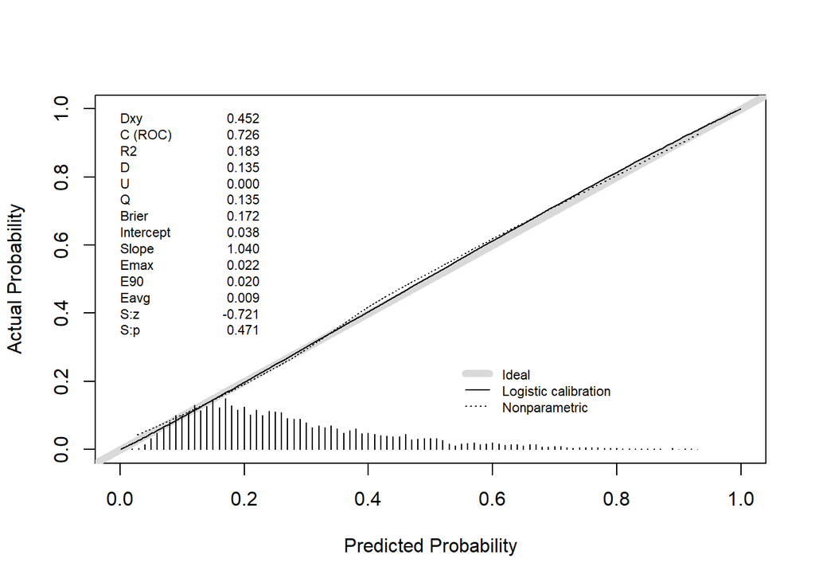

```
          Dxy       C (ROC)            R2             D      D:Chi-sq
 4.522282e-01  7.261141e-01  1.827349e-01  1.352125e-01  8.783940e+02
          D:p             U      U:Chi-sq           U:p             Q
           NA -1.420551e-04  1.078205e+00  5.832716e-01  1.353546e-01
        Brier     Intercept         Slope          Emax           E90
 1.724781e-01  3.834680e-02  1.039541e+00  2.166751e-02  2.036922e-02
         Eavg           S:z           S:p
 9.047517e-03 -7.213620e-01  4.706868e-01
```

```r
rms::val.prob(logit = predict(m2, re.form = NULL), y = pisa2018$bel01)
```

Randomized quantile residuals. Note that outlier tests may have inflated error rates and are likely not relevant here. We plot them here also against the focal predictors as non-covariates to assess wether they are important to describe the outcome.

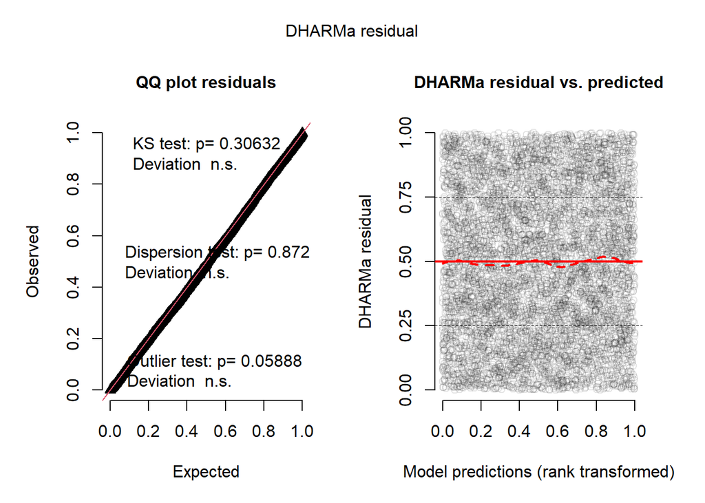

```r
s = simulateResiduals(m2, seed = 26, plot = TRUE)
```

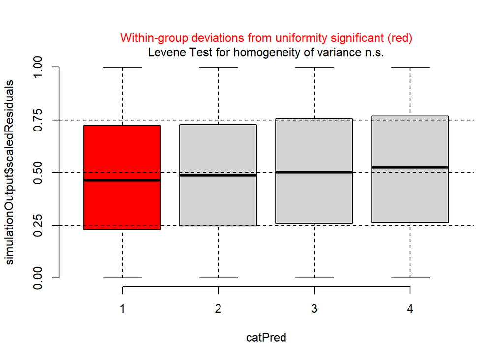

```r
plotResiduals(s, pisa2018$ATT4)
```

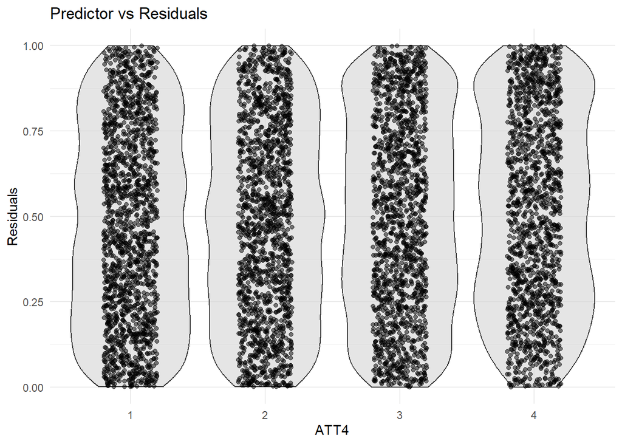

```r
plot_residuals_violin(s, pisa2018$ATT4, "ATT4")
```

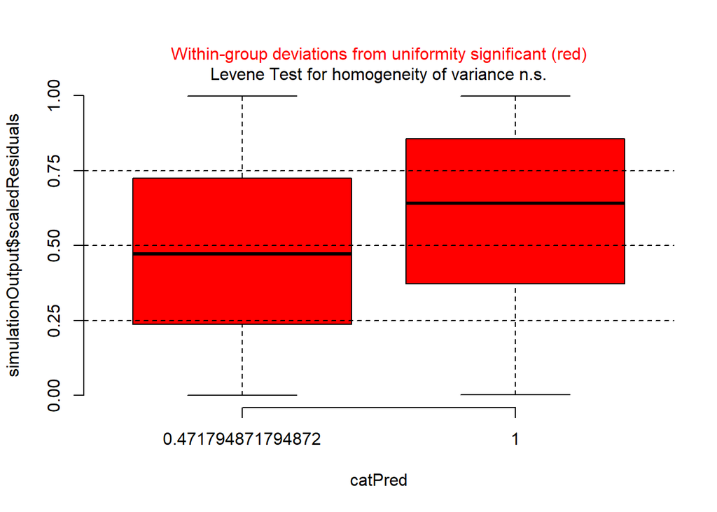

```r
plotResiduals(s, pisa2018$bull)
```

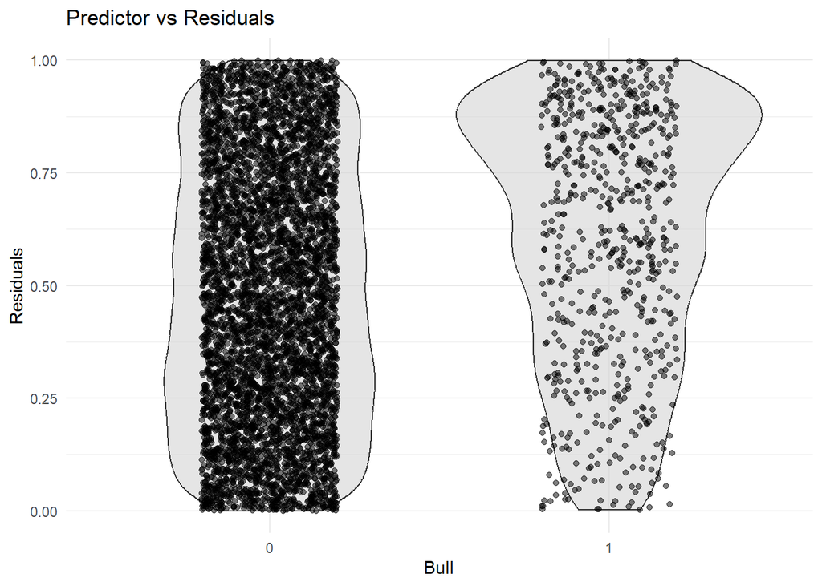

```r
plot_residuals_violin(s, pisa2018$bull, "Bull")
```

Random effect distribution (qq-plot for normality).

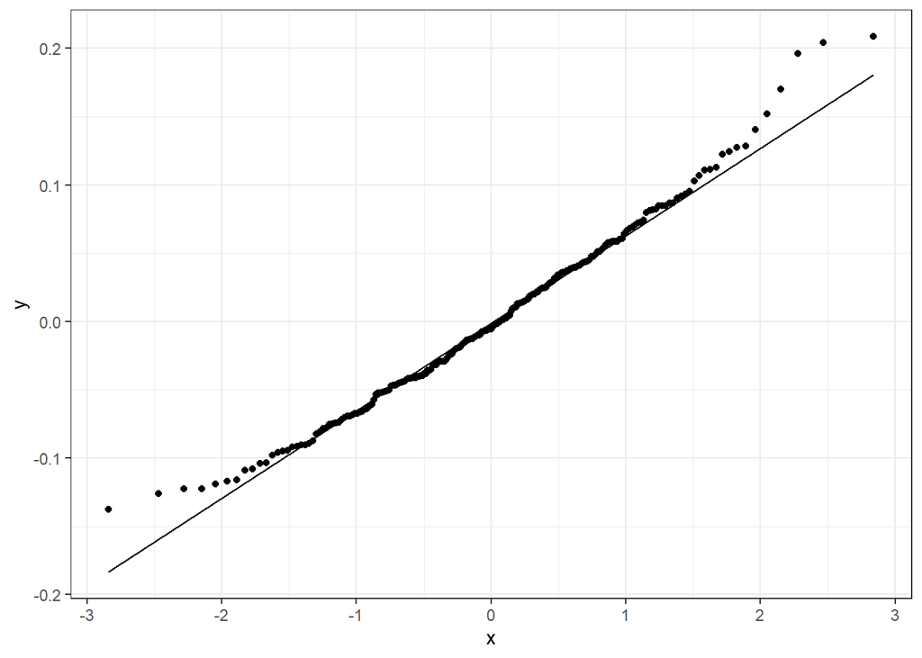

```r
ggplot(ranef(m2)$school.id, aes(sample = `(Intercept)`)) +
        stat_qq() +
        stat_qq_line() +
        theme_bw()
```

## 4.3 Model comparison

Compare models in terms of a likelihood ratio test to assess if the secondary model would describe the data as well as the primary model.

The test is significant, indicating the the larger model “better” describes the data based on frequentist likelihood theory. Also the AIC and BIC criteria are smaller for the larger model, indicating it is to be preferred despite the larger number of fixed effects. This is to be taken together with the results from the randomized quantile residuals, which also indicated a lack of fit for the focal predictors.

```r
anova(m, m2)
```

|  | npar | AIC | BIC | logLik | deviance | Chisq | Df | Pr(>Chisq) |
| --- | --- | --- | --- | --- | --- | --- | --- | --- |
| m2 | 17 | 6878.317 | 6993.541 | -3422.158 | 6844.317 | NA | NA | NA |
| m | 24 | 6679.842 | 6842.510 | -3315.921 | 6631.842 | 212.4753 | 7 | 0 |

## 4.4 Bootstrap

Simulate 1000 bootstraps for full model. The bootstrap is done at cluster level (i.e. schools).

### 4.4.1 Bootstrap indices

```r
set.seed(13376)
b = 1000
sids = unique(pisa2018$school.id)
bootstraps = map(1:b, ~ sample(sids, length(sids), replace = TRUE))

glue("Statistics of relative frequency of unique schools per bootstrap:")
```

```
Statistics of relative frequency of unique schools per bootstrap:
```

```r
(map_dbl(bootstraps, n_distinct) / length(sids)) %>% summary()
```

```
   Min. 1st Qu.  Median    Mean 3rd Qu.    Max.
 0.5475  0.6199  0.6335  0.6344  0.6471  0.6923
```

### 4.4.2 Run bootstrap

```r
f_b = sprintf("bel01 ~ bull * ATT4 + %s + (1 | school.id)",
              paste0(VARIABLES$nonfocal, collapse = " + ")) %>%
    as.formula()

do_bootstrap <- function(df, ind, f_b, VARIABLES) {
    # construct bootstrap sample
    # first take schools in bootstrap, then give them unique ids
    newids = set_names(ind, 1:length(ind))
    df_bi = map_df(1:length(newids),
                   ~ df %>%
                       filter(school.id == newids[.x]) %>%
                       mutate(school.id = names(newids)[.x]))

    # fit model
    m_bi = glmer(f_b, data = df_bi, family = "binomial")

    preddf_bi = df_bi %>%
        select(bull, ATT4, one_of(VARIABLES$nonfocal)) %>%
        # 1) create subsets of data by focal predictors
        group_by(bull, ATT4) %>%
        # 2) compute 1st, 2nd, 3rd quartiles in subsets
        reframe(
            across(everything(), ~ quantile(.x, probs = c(0.25, 0.5, 0.75))),
            quantile = 1:3
        )

    preddf_bi$pred_bi = predict(m_bi, newdata = preddf_bi, re.form = NA)
    preddf_bi$pred_bi_prob = expit(preddf_bi$pred_bi)

    rf = ranef(m_bi)$school.id[, 1]
    preddf_bi %<>%
        rowwise() %>%
        mutate(pred_bi_marg = mean(pred_bi + rf),
               pred_bi_marg_prob = mean(expit(pred_bi + rf))) %>%
        ungroup()

    list(
        preddf_bi = preddf_bi %>% select(bull, ATT4, quantile,
                                         pred_bi, pred_bi_prob,
                                         pred_bi_marg, pred_bi_marg_prob),
        optinfo = m_bi@optinfo,
        nrow = nrow(df_bi),
        rf = rf
    )
}
```

```r
file_bootstrap = file.path(params$folder_analysis,
                           sprintf("bootstrap-logistic%s.rds", SUFFIX))
if (!file.exists(file_bootstrap)) {
    glue("Running bootstraps and saving to {file_bootstrap}") %>% print()

    plan(multisession, workers = 12)
    res_b = foreach(
        i = seq_along(bootstraps),
        .errorhandling = "pass",
        .options.future = list(seed = 15)
    ) %dofuture%  {
        t_start = Sys.time()
        res = do_bootstrap(pisa2018, bootstraps[[i]], f_b, VARIABLES)
        res$runtime = difftime(now(), t_start, units = "s") %>% as.numeric()
        res
    }
    plan(sequential)
    saveRDS(res_b, file_bootstrap)
} else {
    glue("Reading bootstrap results from {file_bootstrap}") %>% print()
    res_b = readRDS(file_bootstrap)
}
```

```
Reading bootstrap results from Data/Processed/School_FSAP/bootstrap-logistic.rds
```

```r
glue("Runtime per bootstrap in hours:")
```

```
Runtime per bootstrap in hours:
```

```r
summary(map_dbl(res_b, 'runtime')) / 3600
```

```
    Min.  1st Qu.   Median     Mean  3rd Qu.     Max.
0.004891 0.008406 0.010461 0.013173 0.016581 0.043754
```

### 4.4.3 Convergence

```r
res_b %>% map_chr(~ .x$optinfo$message) %>% table()
```

```
.
      failure to converge in 10000 evaluations
                                             1
parameter values converged to within tolerance
                                           999
```

### 4.4.4 Insights

Random effect variances.

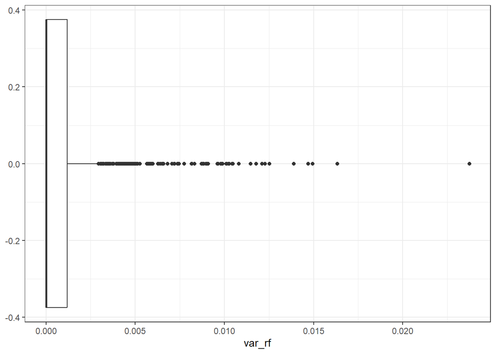

```r
res_b %>%
    map_dfr( ~ data.frame(rf = .x$rf), .id = "bootstrap") %>%
    group_by(bootstrap) %>%
    summarise(
        var_rf = var(rf)
    ) %>%
    ggplot(aes(x = var_rf)) +
    geom_boxplot() +
    theme_bw()
```

# 5 Final result

Display target estimands and variability as table. We sort by bullying, to ease comparison across levels of ATT and quantiles.

These confidence intervals reflect the variability of the marginalized probability estimates.

```r
res_b_summary = bind_rows(map(res_b, "preddf_bi")) %>%
    group_by(bull, ATT4, quantile) %>%
    reframe(
        pred_marg_prob = quantile(pred_bi_marg_prob, probs = c(0.025, 0.25, 0.75, 0.975)),
        pred_quantile = c("q2.5", "q25", "q75", "q97.5")
    ) %>%
    pivot_wider(id_cols = c(bull, ATT4, quantile),
                names_from = pred_quantile,
                values_from = pred_marg_prob)

res = preddf %>%
    select(bull, ATT4, quantile, pred_marg_prob = pred_m_marg_prob) %>%
    left_join(res_b_summary, by = c("bull", "ATT4", "quantile"))

res$result = sprintf("%s<br>50%% [%s, %s]<br>95%% [%s, %s]",
                   round(res$pred_marg_prob, 2),
                   round(res$q25, 2), round(res$q75, 2),
                   round(res$q2.5, 2), round(res$q97.5, 2))

res %>%
    select(bull, ATT4, quantile, result) %>%
    pivot_wider(id_cols = c(ATT4, quantile),
                names_from = bull, values_from = result) %>%
    arrange(ATT4, quantile) %>%
    gt() %>%
    tab_style(
        style = list(cell_fill("#EEEEEE")),
        locations = cells_body(rows = ATT4 %in% c(2, 4))
    ) %>%
    fmt_markdown(columns = everything()) %>%
    cols_align("center", c("0", "1")) %>%
    tab_spanner(label = "bull", columns = c("0", "1")) %>%
    tab_options(quarto.disable_processing = TRUE)
```

[output not shown]

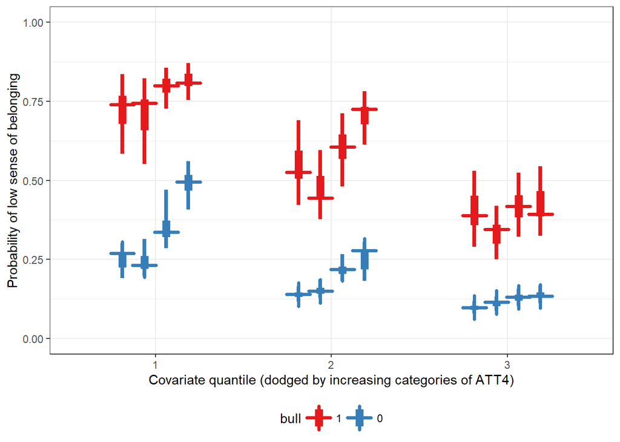

```r
ggplot(res, aes(group = ATT4, y = pred_marg_prob, color = fct_rev(factor(bull)),
                x = factor(quantile))) +
    geom_linerange(aes(ymin = q2.5, ymax = q97.5), position = position_dodge(0.5),
                   linewidth = 1.5) +
    geom_linerange(aes(ymin = q25, ymax = q75), position = position_dodge(0.5),
                   linewidth = 3) +
    geom_point(position = position_dodge(0.5), size = 5, stroke = 2, shape = 3) +
    scale_color_brewer(palette = "Set1", name = "bull") +
    coord_cartesian(ylim = c(0, 1)) +
    ylab("Probability of low sense of belonging") +
    xlab("Covariate quantile (dodged by increasing categories of ATT4)") +
    theme_bw() +
    theme(legend.position = "bottom")
```

# 6 Further notes

- Convergence: the models had some trouble with convergence as the random intercepts lead to models that are (close to being) singular. In particular within the bootstrap this leads to the situation that the optimiser says it converged, while lme4 specific diagnostics say it didn’t. Likely that does not matter, as we also did some case studies with `allFit` which indicated that all optimisers say they converged. In any case we switched back to the default “Nelder Mead” optimiser after some testing for the analysis, as it seemed the most robust.
- RF variance: because it is so low overall we do not provide further CIs that reflect RF variance.

# 7 Conclusions

Overall model convergence seemed satisfactory across the bootstrap samples given the insights above. Random intercepts for schools reflect the sampling strategy but do not capture much of the residual variance. In general the presented modeling strategy should provide an adequate estimate for the desired target estimands.

Bullying consistently leads to a drop in sense of belonging across all levels of school truancy and all representative student values (i.e. subset quartiles). This is expressed by a higher probability of being in group of students with sense of belonging lower than the 25% quantile. These differences are are also demonstrated by non-overlapping confidence intervals in all scenarios.

# 8 Sessioninfo

To build this notebook:

- install `quarto`
- make sure the data is in the correct folder (either in global Data folder, or as subfolder of the folder containing this notebook).
- build using the `make.R` script (global Data), or using the Render button in RStudio (subfolder Data).

```r
params
```

```
$folder_analysis
[1] "Data/Processed/School_FSAP"
```

```r
glue("Runtime {difftime(Sys.time(), T_START, units = 'm') / 60} hours.")
```

```
Runtime 0.0163992875152164 hours.
```